# Introducción a la Estadística

2022-07-11

## ¿Qué es la Estadística?

Es un **término que suena familiar** (medios de comunicación que citan cierto **estudio estadístico, encuestas electorales, partidos de fútbol**, etc.) Curiosidad: aunque la disciplina es la estadística, en estos casos hablamos de estadísticas en plural (simplemente recopilación de datos).

**Etimología**: proviene del latín **statisticum collegium** (“Consejo de Estado”) y de su derivado italiano statista (“hombre de Estado o político”). En 1749, el alemán Gottfried Achenwall comenzó a utilizar la palabra alemana statistik para designar el **análisis de datos que recopilaba el Estado**. Por lo tanto, los orígenes de la estadística están relacionados con el gobierno y sus cuerpos administrativos (v.gr. La gran epidemia de cólera de 1854; la enfermera Florence Nightingale en la guerra de Crimea de 1853)

## ¿Qué es la Estadística?

Muchas definiciones y muy variadas

Posible definición: **Es una disciplina que trabaja con datos cuyo objetivo consiste en hacer inferencia, mediante técnicas matemáticas y teoría de probabilidades**.

La estadística es una **disciplina imperialista** que puede ser aplicada a casi cualquier ciencia. Se valen de la estadística para entender e interpretar cuestiones que hacen a sus objetos de estudio.

## ¿Una disciplina controversial?

Tiene mala prensa, a veces se la considera poco seria (Huff, 2011,“Cómo mentir con estadísticas”). Y lo peor es que hay motivos…

*“El 25 % de la población argentina accede a transacciones para tenencia en moneda extranjera… En particular, el funcionario detalló que 4.798.952 personas accedieron a la compra del dólar ahorro por un monto de 3061 millones de dólares.*

*…[U]n ex director del Indec señaló que las declaraciones del funcionario representan “una nueva prueba de la ligereza con que el Gobierno maneja las estadísticas”…“aquél es el número de operaciones registradas, no de personas”. Además, “dado que una persona autorizada a comprar por la AFIP pudo haber realizado 12 compras en el año, el total de personas sería de unas 400.000, o sea el 1% de la población total o el 2% de la PEA…”.*

[Extraído de un artículo de La Nación](http://www.lanacion.com.ar/1758015-para-capitanich-el-cepo-no-existe)

## ¿Una disciplina controversial?

[figure not shown]

## ¿Una disciplina controversial?

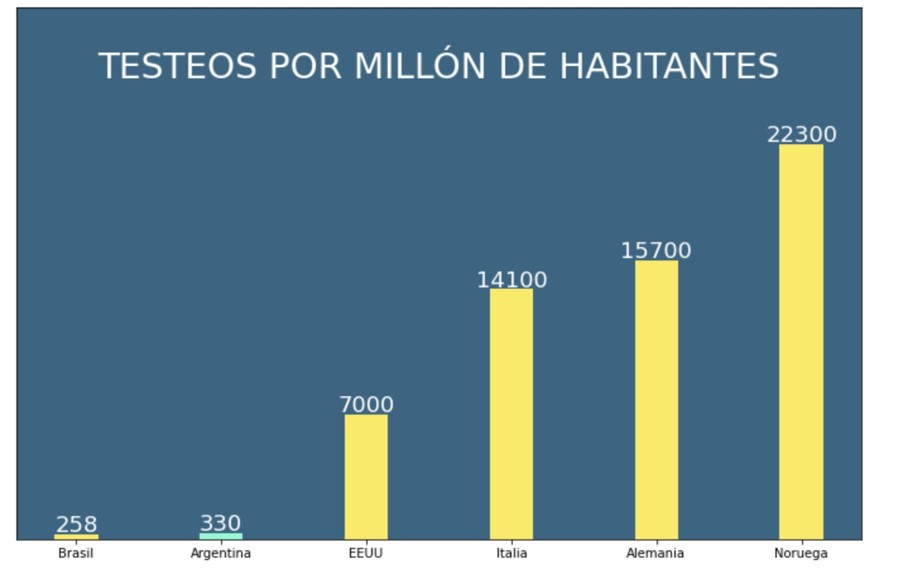

[Fuente: usuario de Twitter @fernandezpablo](https://twitter.com/fernandezpablo/status/1249493191944032256?s=09)

## ¿Una disciplina controversial?

No sólo en Argentina…

[figure not shown]

## ¿Una disciplina controversial?

- ¿Es una rama de la matemática?
- Fuerte contraste de la estadística vs. la solidez y certidumbre de la matemática.
- La estadística estudia como recoger datos( ¿cuántos?, ¿de qué forma?) y cómo analizarlos para obtener información que permita responder las preguntas que uno se plantea.
- Se trata de avanzar en el conocimiento a partir de la observación y el análisis de la realidad, de manera objetiva. **Es la esencia del método científico**.